# UNTITLED FINAL

## **SCATTERPLOT WITH TREND LINE**

INSIGHTS:

- Wealthier countries generally have higher careseeking rates due to better healthcare systems.
- Some lower-income countries maintain high careseeking rates, showing that health policies and outreach matter.
- The scatterplot reveals that GDP alone does not fully explain careseeking behavior; non-economic factors like government prioritization of healthcare, access to education, and public health infrastructure play a significant role.
- A few high-income countries also exhibit lower careseeking rates, suggesting that economic wealth doesn't automatically translate into effective healthcare utilization without supporting policies and services.

```python
import plotly.express as px

# Drop NaN values for the relevant columns
plot_df = merged_df.dropna(subset=['GDP per capita (constant 2015 US$)', 'obs_value'])

# Round off 'obs_value' to 2 decimal places using .loc
plot_df.loc[:, 'obs_value'] = plot_df['obs_value'].round(2)

# Create an enhanced scatter plot
fig = px.scatter(
    plot_df,
    x='GDP per capita (constant 2015 US$)',
    y='obs_value',
    color='obs_value',
    color_continuous_scale='Viridis',  # Better color scale for density
    trendline='ols',
    trendline_color_override='black',  # Make the trendline clean black
    title='GDP PER CAPITA Vs. CHILDREN SEEKING TREATMENT FOR ARI (%)',
    labels={
        'GDP per capita (constant 2015 US$)': 'GDP per Capita (constant 2015 US$)',
        'obs_value': 'Care-Seeking Percentage'
    },
    hover_data={'obs_value':':.2f'} # Format hover data to 2 decimal places
)

# Update layout for a more elegant look
fig.update_layout(
    title_font_size=22,
    plot_bgcolor='white',  # White background
    xaxis=dict(
        gridcolor='lightgray',
        zeroline=False
    ),
    yaxis=dict(
        gridcolor='lightgray',
        zeroline=False
    ),
    coloraxis_colorbar=dict(
        title='Care-Seeking Percentage',
        tickformat='.2f'  # Format colorbar ticks to 2 decimal places
    )
)
fig.update_layout(
    coloraxis_colorbar=dict(
        title="ARI Treatment (%)",  # <-- Change this text!
        title_side="right",            # Make the title above the color bar
        title_font=dict(size=14),    # Optional: control font size
    ),
)
# Display the plot
fig.show()
```

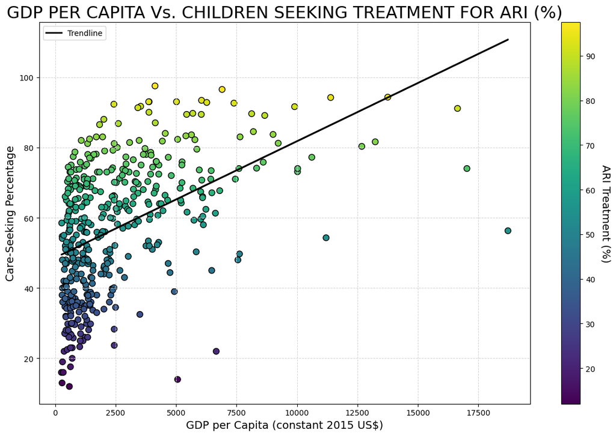

```python
import matplotlib.pyplot as plt
import seaborn as sns
import numpy as np
import pandas as pd

# Drop NaN values for relevant columns
plot_df = merged_df.dropna(subset=['GDP per capita (constant 2015 US$)', 'obs_value'])

# Round off 'obs_value' to 2 decimal places
plot_df.loc[:, 'obs_value'] = plot_df['obs_value'].round(2)

# Set up the plot
plt.figure(figsize=(12, 8))
scatter = plt.scatter(
    plot_df['GDP per capita (constant 2015 US$)'],
    plot_df['obs_value'],
    c=plot_df['obs_value'],
    cmap='viridis',
    edgecolor='k',
    s=60  # size of points
)

# Add a trendline using numpy polyfit (1st degree = linear)
z = np.polyfit(plot_df['GDP per capita (constant 2015 US$)'], plot_df['obs_value'], 1)
p = np.poly1d(z)
plt.plot(
    plot_df['GDP per capita (constant 2015 US$)'],
    p(plot_df['GDP per capita (constant 2015 US$)']),
    color='black',
    linewidth=2,
    label='Trendline'
)

# Titles and labels
plt.title('GDP PER CAPITA Vs. CHILDREN SEEKING TREATMENT FOR ARI (%)', fontsize=22)
plt.xlabel('GDP per Capita (constant 2015 US$)', fontsize=14)
plt.ylabel('Care-Seeking Percentage', fontsize=14)

# White background and light grid
plt.gca().set_facecolor('white')
plt.grid(color='lightgray', linestyle='--', linewidth=0.7)
plt.legend()

# Colorbar
cbar = plt.colorbar(scatter)
cbar.set_label('ARI Treatment (%)', rotation=270, labelpad=20, fontsize=14)
cbar.ax.tick_params(labelsize=10)

# Show the plot
plt.tight_layout()
plt.show()
```

KEY HIGHLIGHT: Economic development positively influences careseeking, but strong health policies and public health efforts are critical in ensuring high careseeking rates, even in lower-income countries.